# ANA 1005: Enterprise Analytics Assignment 4

Student Number: A00240954  
Student Name: Aaron Rebuldela

Below code will install the Kaggle API, mount the Google Drive, set the Kaggle credentials, and download the dataset to a datasets folder in Google Drive.

```python
!pip install kaggle
```

```python
from google.colab import drive
drive.mount('/content/drive')
```

```python
import os
os.environ['KAGGLE_USERNAME'] = "aaronrebuldela"
os.environ['KAGGLE_KEY'] = "13d655dd3f535b739e77182452766815"

!kaggle datasets download -d prasertk/historical-commodity-prices-from-20002022 -p /content/drive/MyDrive/datasets
```

```
historical-commodity-prices-from-20002022.zip: Skipping, found more recently modified local copy (use --force to force download)
```

```python
import pandas as pd

df = pd.read_csv('/content/drive/MyDrive/datasets/historical-commodity-prices-from-20002022.zip')
```

Dataset chosen is: Major commodity prices from 2000-2022 (Gold, Palladium, Nickel, Brent Oil, Natural Gas, and Wheat) link: https://www.kaggle.com/datasets/prasertk/historical-commodity-prices-from-20002022

**PART 1: Below Exploratory Analysis:**

a. Look at the first few rows using the head() method.

```python
df.head()
```

|  | Symbol | Date | Open | High | Low | Close | Volume |
| --- | --- | --- | --- | --- | --- | --- | --- |
| 0 | Gold | 2000-01-04 | 281.0 | 281.0 | 281.0 | 282.7 | 4 |
| 1 | Gold | 2000-01-05 | 283.2 | 283.2 | 283.2 | 281.1 | 16 |
| 2 | Gold | 2000-01-06 | 281.4 | 281.4 | 281.4 | 281.4 | 0 |
| 3 | Gold | 2000-01-07 | 281.9 | 281.9 | 281.9 | 281.9 | 0 |
| 4 | Gold | 2000-01-10 | 281.7 | 281.7 | 281.7 | 281.7 | 0 |

b. Check at the unique values in the Symbol column using unique() method.

```python
# get the unique names/symbols in the 'Name' column
unique_names = df['Symbol'].unique()
unique_names
```

```
array(['Gold', 'Palladium', 'Nickel', 'Brent Oil', 'Natural Gas',
       'US Wheat'], dtype=object)
```

c. Check the shape and size of the dataset using the shape attribute and len() function

```python
print(df.shape)  # prints the number of rows and columns in the dataset
print(len(df))   # prints the number of rows in the dataset
```

```
(29935, 7)
29935
```

d. Identify the data types of each column using the dtypes attribute.

```python
print(df.dtypes)  # prints the data types of each column
```

```
Symbol     object
Date       object
Open      float64
High      float64
Low       float64
Close     float64
Volume      int64
dtype: object
```

e. Check for missing values in the dataset using the isnull() method and visualize the missing data

```
Symbol    0
Date      0
Open      0
High      0
Low       0
Close     0
Volume    0
dtype: int64
```

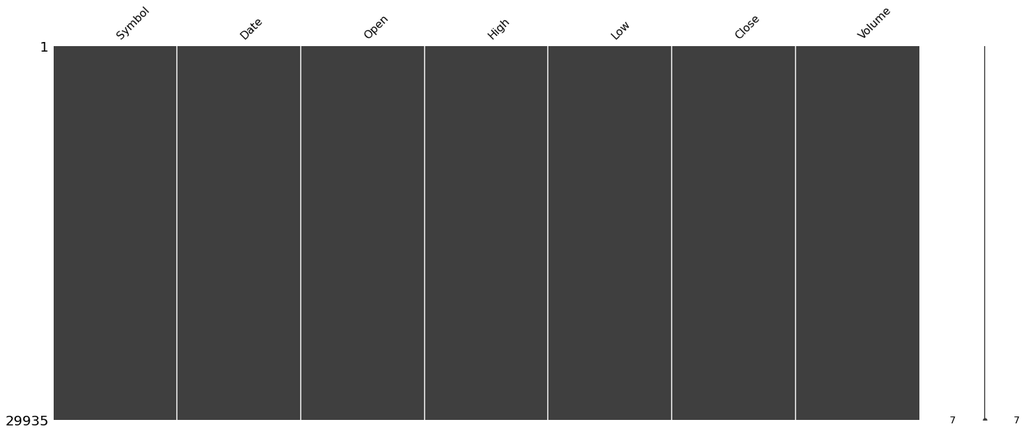

```python
import missingno as msno  # import the missingno library

# check for missing values using isnull() and sum() methods
print(df.isnull().sum())

# visualize the missing data using a heatmap
msno.matrix(df)
```

f. Calculate basic statistics for each numerical column using the describe() method

```python
print(df.describe())  # prints basic statistics for each numerical column
```

```
               Open          High           Low         Close        Volume
count  29935.000000  29935.000000  29935.000000  29935.000000  2.993500e+04
mean    2199.912965   2217.497624   2183.193574   2200.980681  5.272722e+04
std     5054.172000   5088.374345   5024.451547   5054.979572  8.280148e+04
min        0.000000      0.000000      0.000000      1.482000  0.000000e+00
25%       48.075000     48.975000     47.265000     48.140000  1.000000e+00
50%      431.300000    435.500000    428.000000    431.400000  1.157100e+04
75%     1165.300000   1173.050000   1158.050000   1168.600000  7.218800e+04
max    81066.500000  86791.500000  81031.500000  81051.500000  1.083978e+06
```

**Part 2 and 3: Get Five Questions of your choice (make sure you answer with a visualization and provide interpretation too). Dataset should not match with your Final project select a different dataset**

a. What is the overall trend of gold prices over time? Visualize the daily closing prices using a line chart and identify any significant peaks or troughs in the price?

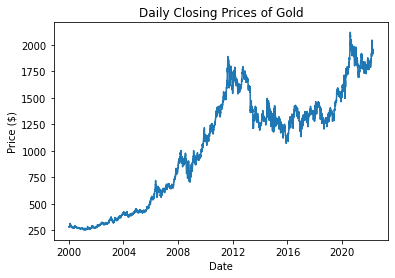

```python
import matplotlib.pyplot as plt

# subset the data for gold prices
gold_df = df[df['Symbol'] == 'Gold']

# convert the 'Date' column to a datetime object
gold_df['Date'] = pd.to_datetime(gold_df['Date'])

# set the 'Date' column as the index
gold_df.set_index('Date', inplace=True)

# create a line chart of the daily closing prices
plt.plot(gold_df['Close'])

# add a title and labels
plt.title('Daily Closing Prices of Gold')
plt.xlabel('Date')
plt.ylabel('Price ($)')

# show the chart
plt.show()
```

Answer(a): According to chart there is significant peaks near year 2012 and after 2019. Generally the trend is upward(increasing) from 2000 to 2022

b. Averaging the price by month for the past 5 years, Is there some seasonal changes or trends (compare)?

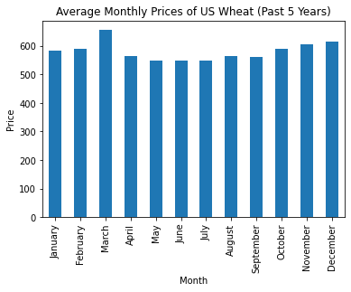

```python
# subset the data for US wheat prices
us_wheat_df = df[df['Symbol'] == 'US Wheat']

# convert the 'Date' column to a datetime object
us_wheat_df['Date'] = pd.to_datetime(us_wheat_df['Date'])

# filter the data for the past five years
five_years_ago = pd.Timestamp.now().year - 5
us_wheat_df = us_wheat_df[us_wheat_df['Date'].dt.year >= five_years_ago]

# group the data by month and calculate the average closing price
us_wheat_monthly = us_wheat_df.groupby(us_wheat_df['Date'].dt.strftime('%B'))['Close'].mean()

# sort the index of the resulting Series in chronological order
month_order = ['January', 'February', 'March', 'April', 'May', 'June', 'July', 'August', 'September', 'October', 'November', 'December']
us_wheat_monthly = us_wheat_monthly.reindex(month_order)

# create a bar chart of the average monthly prices
us_wheat_monthly.plot(kind='bar')

# add a title and labels
plt.title('Average Monthly Prices of US Wheat (Past 5 Years)')
plt.xlabel('Month')
plt.ylabel('Price')

# show the bar chart
plt.show()
```

Answer(b): For past 5 years, There is a significant uptick or difference in US wheat price at the month of March compared to other months. From June to December the trend is going upward(towards the holiday season).

[figure not shown]

```python
import seaborn as sns
# subset the data for nickel and gold prices
ng_df = df[['Date', 'Close', 'Symbol']][df['Symbol'] == 'Natural Gas']
gold_df = df[['Date', 'Close', 'Symbol']][df['Symbol'] == 'Gold']

# convert the 'Date' column to a datetime object
ng_df['Date'] = pd.to_datetime(ng_df['Date'])
gold_df['Date'] = pd.to_datetime(gold_df['Date'])

# merge the data frames based on the 'Date' column
merged_df = pd.merge(ng_df, gold_df, on='Date', how='outer')

# create a scatter plot of the prices
sns.scatterplot(x='Close_x', y='Close_y', data=merged_df)

# add a title and labels
plt.title('Relationship Between Nickel and Gold Prices')
plt.xlabel('Natural Gas Price')
plt.ylabel('Gold Price')

# show the plot
plt.show()
```

d. Is there some relationship between the changes in prices of US Wheat and Brent Oil?

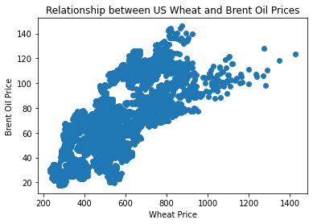

```python
# subset the data for wheat and brent oil prices
wheat_brent_df = df[df['Symbol'].isin(['US Wheat', 'Brent Oil'])]

# convert the 'Date' column to a datetime object
wheat_brent_df['Date'] = pd.to_datetime(wheat_brent_df['Date'])

# pivot the data to have separate columns for wheat and brent oil prices
wheat_brent_pivot = wheat_brent_df.pivot(index='Date', columns='Symbol', values='Close')

# plot a scatter plot of the wheat and brent oil prices
plt.scatter(x=wheat_brent_pivot['US Wheat'], y=wheat_brent_pivot['Brent Oil'])

# add a title and labels
plt.title('Relationship between US Wheat and Brent Oil Prices')
plt.xlabel('Wheat Price')
plt.ylabel('Brent Oil Price')

# show the plot
plt.show()
```

Answer(d): Based on the scatter plot chart, there appears to be a relationship between US Wheat and Brent Oil prices. The data suggests that as the Brent Oil price increases, the Wheat price also tends to increase.

e. Is there a correlation or similarity in the price change patterns over time between US Wheat and Gold prices?

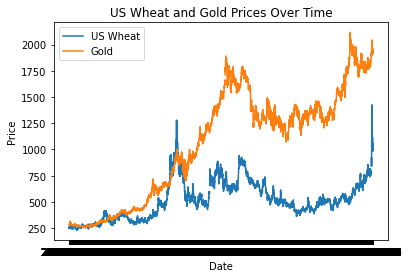

```python
# subset the data for US wheat and gold prices
us_wheat_gold_df = df[['Symbol', 'Date', 'Close']].loc[df['Symbol'].isin(['US Wheat', 'Gold'])]

# pivot the data to put each commodity in a separate column
us_wheat_gold_pivot = us_wheat_gold_df.pivot(index='Date', columns='Symbol', values='Close')

# create a line chart of the US wheat and gold prices over time
plt.plot(us_wheat_gold_pivot['US Wheat'], label='US Wheat')
plt.plot(us_wheat_gold_pivot['Gold'], label='Gold')

# add a title and labels
plt.title('US Wheat and Gold Prices Over Time')
plt.xlabel('Date')
plt.ylabel('Price')
plt.legend()

# show the chart
plt.show()
```

Answer(e): Based on the line chart, it appears that there is no significant correlation or similarity in the price change patterns between US Wheat and Gold over time.